# Assignment 1

Faraz Ahmadi

08 October 2020

# 1 Statement of authorship

I have executed and prepared this assignment and document by myself without the help of any other person. Signature:

# 2 Ice Cream Survey analysis

This work is a preliminary data analysis task done on a survey data set done on ice cream brands. Its purpose is to clean and prepare the data set so that it can be used most easily by the analysts. This data set accompanies the “Seven Summits of Marketing Research” text by Greg Allenby and Jeff Brazell and is used with their permission.

[figure not shown]

```r
knitr::include_graphics("./ice_cream.png")
```

[figure not shown]

```r
knitr::include_graphics("./survey.png")
```

## 2.1 Reading the Ice Cream data set

The first step is to load the data and required packages.

```r
library(dplyr)
library(psych)
library(DT)
library(tidyverse)
ic<- read.csv("./IceCream_raw.csv")
#ic<- read.csv("http://bus-sawtooth.mcmaster.ca/M733_ONLINE_F2020/IceCream_raw.csv")
```

and take a glance at what it offers.

```r
headTail(ic) %>% datatable( rownames = TRUE, filter="top", options = list(pageLength = 10, scrollX=T))
```

|  | ID | StartTime | EndTime | ILength | S1 | S2 | S3 | S4 | S5 | S6_1 | S6_2 | S6_3 | S6_4 | S6_5 | S6_6 | S6_99 | S6_6_Ospec | S7_1 | S7_2 | S7_3 | S7_4 | S7_5 | S7_6 | S7_7 | S7_99 | S8_1 | S8_2 | S8_3 | S8_4 | … |
| --- | --- | --- | --- | --- | --- | --- | --- | --- | --- | --- | --- | --- | --- | --- | --- | --- | --- | --- | --- | --- | --- | --- | --- | --- | --- | --- | --- | --- | --- | --- |
| 1 | 10834603 | 07-27-2011 08:16 PM | 07-27-2011 08:54 PM | 2241 | 2 | 4 | 2 | 2 | kirkland | 1 | 2 | 3 | 4 | 5 | 0 | 0 |  | 1 | 2 | 3 | 4 | 5 | 6 | 7 | 0 | 0 | 0 | 0 | 0 | … |
| 2 | 10834607 | 07-27-2011 08:18 PM | 07-27-2011 08:38 PM | 1208 | 1 | 3 | 1 | 9 | Edy's | 1 | 0 | 0 | 0 | 5 | 0 | 0 |  | 1 | 2 | 3 | 4 | 5 | 6 | 7 | 0 | 0 | 0 | 3 | 4 | … |
| 3 | 10834617 | 07-27-2011 08:19 PM | 07-27-2011 08:32 PM | 786 | 1 | 5 | 3 | 2 | edy's | 0 | 0 | 3 | 0 | 0 | 0 | 0 |  | 0 | 0 | 0 | 4 | 5 | 6 | 7 | 0 |  |  |  | 4 | … |
| 4 | 10834627 | 07-27-2011 08:20 PM | 07-27-2011 08:53 PM | 1941 | 1 | 3 | 1 | 5 | kroger dellux | 1 | 2 | 3 | 0 | 5 | 0 | 0 |  | 1 | 2 | 3 | 4 | 5 | 6 | 7 | 0 | 0 | 2 | 0 | 4 | … |
| ... | ... |  |  | ... | ... | ... | ... | ... |  | ... | ... | ... | ... | ... | ... | ... |  | ... | ... | ... | ... | ... | ... | ... | ... | ... | ... | ... | ... | … |
| 598 | 10844789 | 07-31-2011 07:34 PM | 07-31-2011 07:45 PM | 658 | 1 | 3 | 2 | 6 | Tillamook | 1 | 2 | 3 | 0 | 0 | 0 | 0 |  | 1 | 2 | 0 | 4 | 5 | 6 | 7 | 0 | 1 | 0 |  | 0 | … |
| 599 | 10844793 | 07-31-2011 07:38 PM | 07-31-2011 07:51 PM | 786 | 1 | 5 | 5 | 1 | sealtest | 1 | 0 | 0 | 0 | 0 | 0 | 0 |  | 0 | 2 | 0 | 4 | 5 | 6 | 7 | 0 |  | 0 |  | 0 | … |
| 600 | 10844794 | 07-31-2011 07:41 PM | 07-31-2011 07:56 PM | 940 | 1 | 5 | 4 | 1 | Ben and jerrys | 0 | 0 | 0 | 0 | 5 | 0 | 0 |  | 0 | 2 | 0 | 0 | 5 | 0 | 0 | 0 |  | 0 |  |  | … |
| 601 | 10844801 | 07-31-2011 07:45 PM | 07-31-2011 08:07 PM | 1268 | 1 | 4 | 3 | 3 | Ben and Jerry | 1 | 2 | 3 | 4 | 5 | 0 | 0 |  | 1 | 2 | 0 | 4 | 5 | 6 | 7 | 0 | 0 | 0 |  | 4 | … |

## 2.2 Reducing the raw data to essential variables

In this analysis we are only focusing on the Dreyer’s brand. Based on the questionnaires we only need to analyze certain columns.

```r
d_names <- c(grep("^D.$", names(ic), value = TRUE), "D10")
q11 <- grep("^Q11_", names(ic), value = TRUE)
q11_1 <- grep("^Q11_1_", q11, value = TRUE) ##Only for the Dreyer's brand
s7 <- grep("^S7_", names(ic), value = TRUE)
s8 <- grep("^S8_", names(ic), value = TRUE)
col_names <- c("ID",s7, s8, "Q1_1","Q2_1","Q3_1", q11_1, d_names)
```

The data and its selected variables are depicted below. The S7 and S8 are chose from the screener questions to identify the participants who have heard about or have purchased our brand in the past 6 months. Also the behavioral questions needed for this analysis that are Q1,Q2,Q3 and Q11 are selected for the Dreyer’s brand. Each question is coded with a number in its name that shows the corresponding ice cream brand. The number assigned to the Dreyer’s brand is 1, therefore we choose Q1_1, Q2_1 ,etc.

```r
ic_sub <- ic[col_names]
headTail(ic_sub,5,5) %>% datatable( rownames = TRUE, filter="top", options = list(pageLength = 12, scrollX=T))
```

|  | ID | S7_1 | S7_2 | S7_3 | S7_4 | S7_5 | S7_6 | S7_7 | S7_99 | S8_1 | S8_2 | S8_3 | S8_4 | S8_5 | S8_6 | S8_7 | S8_99 | Q1_1 | Q2_1 | Q3_1 | Q11_1_1 | Q11_1_2 | Q11_1_3 | Q11_1_4 | Q11_1_5 | Q11_1_6 | Q11_1_7 | Q11_1_8 | Q11_1_9 | … |
| --- | --- | --- | --- | --- | --- | --- | --- | --- | --- | --- | --- | --- | --- | --- | --- | --- | --- | --- | --- | --- | --- | --- | --- | --- | --- | --- | --- | --- | --- | --- |
| 1 | 10834603 | 1 | 2 | 3 | 4 | 5 | 6 | 7 | 0 | 0 | 0 | 0 | 0 | 5 | 0 | 7 | 0 |  |  |  |  |  |  |  |  |  |  |  |  | … |
| 2 | 10834607 | 1 | 2 | 3 | 4 | 5 | 6 | 7 | 0 | 0 | 0 | 3 | 4 | 0 | 0 | 7 | 0 |  |  |  | 6 | 4 | 6 | 2 | 4 | 2 | 2 | 5 | 5 | … |
| 3 | 10834617 | 0 | 0 | 0 | 4 | 5 | 6 | 7 | 0 |  |  |  | 4 | 0 | 6 | 0 | 0 |  |  |  |  |  |  |  |  |  |  |  |  | … |
| 4 | 10834627 | 1 | 2 | 3 | 4 | 5 | 6 | 7 | 0 | 0 | 2 | 0 | 4 | 0 | 0 | 7 | 0 |  |  |  | 5 | 6 | 5 | 5 | 4 | 5 | 6 | 5 | 5 | … |
| 5 | 10834662 | 1 | 2 | 3 | 4 | 5 | 6 | 7 | 0 | 0 | 0 | 3 | 0 | 0 | 6 | 7 | 0 |  |  |  |  |  |  |  |  |  |  |  |  | … |
| ... | ... | ... | ... | ... | ... | ... | ... | ... | ... | ... | ... | ... | ... | ... | ... | ... | ... | ... | ... | ... | ... | ... | ... | ... | ... | ... | ... | ... | ... | … |
| 597 | 10844786 | 1 | 2 | 0 | 4 | 5 | 6 | 7 | 0 | 1 | 2 |  | 4 | 0 | 0 | 7 | 0 | 6 | 6 | 6 | 2 | 5 | 3 | 2 | 3 | 5 | 2 | 4 | 2 | … |
| 598 | 10844789 | 1 | 2 | 0 | 4 | 5 | 6 | 7 | 0 | 1 | 0 |  | 0 | 5 | 6 | 0 | 0 | 5 | 6 | 6 | 5 | 3 | 5 | 4 | 4 | 4 | 2 | 5 | 3 | … |
| 599 | 10844793 | 0 | 2 | 0 | 4 | 5 | 6 | 7 | 0 |  | 0 |  | 0 | 0 | 0 | 7 | 0 |  |  |  |  |  |  |  |  |  |  |  |  | … |
| 600 | 10844794 | 0 | 2 | 0 | 0 | 5 | 0 | 0 | 0 |  | 0 |  |  | 5 |  |  | 0 |  |  |  |  |  |  |  |  |  |  |  |  | … |

[output cut: 1 more lines]

## 2.3 Filtering the participants

Starting to inspect the Dryer’s brand. it is evident that many NA values are present in S8 questions. Which by looking at the S7 question (Having heard of this brand) it shows that those are the people who have not heard of this brand and therefore should be omitted from this analysis.

Heard of Dreyer’s Brand

| S7_1 | Freq |
| --- | --- |
| 0 | 247 |
| 1 | 354 |
| NA | 0 |

Purchased Dreyer’s brand in last 6 months

| S8_1 | Freq |
| --- | --- |
| 0 | 234 |
| 1 | 120 |
| NA | 247 |

The following tables shows the participants (rows) that have the S8_1 variable missing. It also shows that these are the people who have not heard of our brand **(S7_1 == 0)**.

```r
ic[is.na(ic["S8_1"]),c("ID", "S7_1", "S8_1","Q1_1","Q2_1","Q3_1" )] %>% datatable( rownames = TRUE, filter="top", options = list(pageLength = 10, scrollX=T))
```

|  | ID | S7_1 | S8_1 | Q1_1 | Q2_1 | Q3_1 |
| --- | --- | --- | --- | --- | --- | --- |
| 3 | 10834617 | 0 |  |  |  |  |
| 9 | 10834836 | 0 |  |  |  |  |
| 18 | 10835023 | 0 |  |  |  |  |
| 19 | 10835028 | 0 |  |  |  |  |
| 21 | 10835608 | 0 |  |  |  |  |
| 23 | 10835907 | 0 |  |  |  |  |
| 24 | 10835946 | 0 |  |  |  |  |
| 25 | 10835982 | 0 |  |  |  |  |
| 26 | 10836073 | 0 |  |  |  |  |
| 27 | 10836079 | 0 |  |  |  |  |

[output cut: 237 more lines]

### 2.3.1 filtering rows

As the variable S7_1 has no missing values and it can effectively identify the people who have not heard of, therefore not purchased the Dreyer’s brand. These are the people who we need to exclude from the analysis and save the remaining subset to **ic_sub_1**

```r
ic_sub_1 <- ic_sub %>% filter(!(S7_1 == 0))
```

Checking the S7_1 and S8_1 in the new filtered data

```r
sjmisc::frq(ic_sub_1$S7_1, out = 'v', title = "Heard of Dreyer's Brand (S7_1)")
```

Heard of Dreyer’s Brand (S7_1)

| val | label | frq | raw.prc | valid.prc | cum.prc |  |
| --- | --- | --- | --- | --- | --- | --- |
| 1 |  | 354 | 100 | 100 | 100 |  |
| NA | NA | 0 | 0 | NA | NA |  |
| total N=354 · valid N=354 · x̄=1.00 · σ=0.00 |  |  |  |  |  |  |

```r
sjmisc::frq(ic_sub_1$S8_1, out = 'v', title = "Purchased Dreyer's brand in last 6 months (S8_1)")
```

Purchased Dreyer’s brand in last 6 months (S8_1)

| val | label | frq | raw.prc | valid.prc | cum.prc |  |
| --- | --- | --- | --- | --- | --- | --- |
| 0 |  | 234 | 66.1 | 66.1 | 66.1 |  |
| 1 |  | 120 | 33.9 | 33.9 | 100 |  |
| NA | NA | 0 | 0 | NA | NA |  |
| total N=354 · valid N=354 · x̄=0.34 · σ=0.47 |  |  |  |  |  |  |

You can see that there is no missing values anymore in these two variables.

## 2.4 Missing values analyses

We filtered our subset of the data for the Dreyer’s brand analysis. Now let’s look at missing values in this subset.

```r
options(max.print = 100000)
library(inspectdf)
ic_sub_1 %>% inspect_na()  %>% datatable( rownames = TRUE, filter="top", options = list(pageLength = 10, scrollX=T))
```

|  | col_name | cnt | pcnt |
| --- | --- | --- | --- |
| 1 | Q1_1 | 234 | 66.1016949152542 |
| 2 | Q2_1 | 234 | 66.1016949152542 |
| 3 | Q3_1 | 234 | 66.1016949152542 |
| 4 | S8_3 | 162 | 45.7627118644068 |
| 5 | Q11_1_1 | 100 | 28.2485875706215 |
| 6 | Q11_1_2 | 100 | 28.2485875706215 |
| 7 | Q11_1_3 | 100 | 28.2485875706215 |
| 8 | Q11_1_4 | 100 | 28.2485875706215 |
| 9 | Q11_1_7 | 100 | 28.2485875706215 |
| 10 | Q11_1_8 | 100 | 28.2485875706215 |

[output cut: 37 more lines]

and the following figures to see the pattern of the missing data.

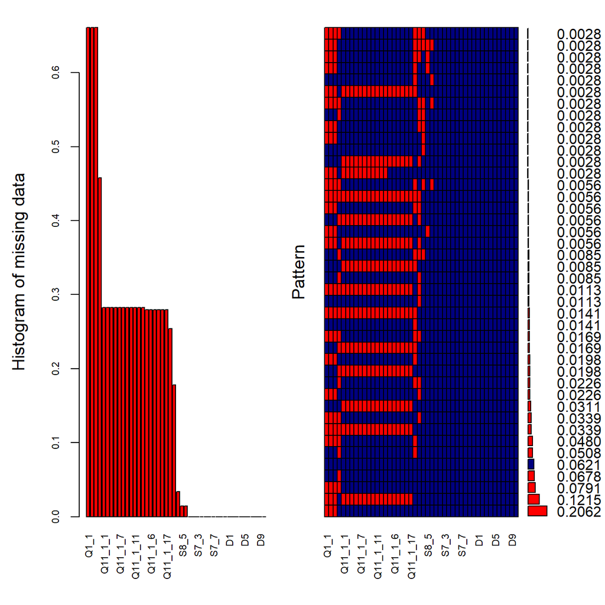

```
 Variables sorted by number of missings:
 Variable      Count
     Q1_1 0.66101695
     Q2_1 0.66101695
     Q3_1 0.66101695
     S8_3 0.45762712
  Q11_1_1 0.28248588
  Q11_1_2 0.28248588
  Q11_1_3 0.28248588
  Q11_1_4 0.28248588
  Q11_1_7 0.28248588
  Q11_1_8 0.28248588
  Q11_1_9 0.28248588
 Q11_1_10 0.28248588
 Q11_1_11 0.28248588
 Q11_1_13 0.28248588
 Q11_1_15 0.28248588
  Q11_1_5 0.27966102
  Q11_1_6 0.27966102
 Q11_1_12 0.27966102
 Q11_1_14 0.27966102
 Q11_1_16 0.27966102
 Q11_1_17 0.27966102
     S8_2 0.25423729
     S8_7 0.17796610
     S8_4 0.03389831
     S8_5 0.01412429
     S8_6 0.01412429
     S7_1 0.00000000
     S7_2 0.00000000
     S7_3 0.00000000
     S7_4 0.00000000
     S7_5 0.00000000
     S7_6 0.00000000
     S7_7 0.00000000
    S7_99 0.00000000
     S8_1 0.00000000
    S8_99 0.00000000
       D1 0.00000000
       D2 0.00000000
       D3 0.00000000
       D4 0.00000000
       D5 0.00000000
       D6 0.00000000
       D7 0.00000000
       D8 0.00000000
       D9 0.00000000
      D10 0.00000000
```

```r
library(VIM)
ic_sub_1[, c(2:47)] %>% aggr(col=c('navyblue','red'), numbers=TRUE, sortVars=TRUE, cex.axis=.7, gap=3, ylab=c("Histogram of missing data","Pattern"))
```

First the S7 and S8 for other brands are removed. Now we look at the remaining variables and their missing counts.

```r
ic_sub_2 <- ic_sub_1[c("ID", "S7_1", "S8_1", "Q1_1", "Q2_1", "Q3_1", q11_1, d_names)]
library(inspectdf)
ic_sub_2 %>% inspect_na %>% datatable( rownames = TRUE, filter="top", options = list(pageLength = 10, scrollX=T))
```

|  | col_name | cnt | pcnt |
| --- | --- | --- | --- |
| 1 | Q1_1 | 234 | 66.1016949152542 |
| 2 | Q2_1 | 234 | 66.1016949152542 |
| 3 | Q3_1 | 234 | 66.1016949152542 |
| 4 | Q11_1_1 | 100 | 28.2485875706215 |
| 5 | Q11_1_2 | 100 | 28.2485875706215 |
| 6 | Q11_1_3 | 100 | 28.2485875706215 |
| 7 | Q11_1_4 | 100 | 28.2485875706215 |
| 8 | Q11_1_7 | 100 | 28.2485875706215 |
| 9 | Q11_1_8 | 100 | 28.2485875706215 |
| 10 | Q11_1_9 | 100 | 28.2485875706215 |

[output cut: 23 more lines]

The demographics variables have no missing values. The subset of S7_1 and S8_1 has no missing point either. We only have 28% missing in Q11 questions and 66% for Q1-Q3. The latter makes total sense because those are the people who have not purchased the product in last 6 months, therefore, have not been asked to answer Q1-Q3 questions. These questions are missing 234 rows which is the same number of people who have not purchased the brand in S8_1. The code below shows this.

```r
ic_sub_2[c("ID", "S7_1", "S8_1", "Q1_1", "Q2_1", "Q3_1")] %>% filter(S8_1 ==0) %>% nrow()
```

```
[1] 234
```

Therefore, the number of missing points in Q1-Q3 is the same as number of people who have not purchased the brand in 6 months and their missing values should not be imputed as it does not make sense to do so!

### 2.4.1 Imputing the valid variables using mice

The only valid variables that require imputation are the seventeen Q11s. So only this subset of our “ic_sub_2” is passed to ‘mice’ function. The following code uses ‘mice’ to generate m=5 new imputed data sets using the Random Forest Imputation method.

```r
library(mice)
set.seed(456)
ic_to_impute <- ic_sub_2[q11_1]
tempData <- mice(ic_to_impute, m=5, maxit=50, meth='rf', seed=500, print=FALSE) # This uses 'mice' to generate m=5 new imputed datasets using the 'rf' method and '500' as a seed to get the process initiated.
```

Taking a look at the imputed subset, it can be seen that there is no missing value anymore.

```r
compData <- mice::complete(tempData, 1)
headTail(compData, 20)  %>% datatable( rownames = TRUE, filter="top", options = list(pageLength = 10, scrollX=T))
```

|  | Q11_1_1 | Q11_1_2 | Q11_1_3 | Q11_1_4 | Q11_1_5 | Q11_1_6 | Q11_1_7 | Q11_1_8 | Q11_1_9 | Q11_1_10 | Q11_1_11 | Q11_1_12 | Q11_1_13 | Q11_1_14 | Q11_1_15 | Q11_1_16 | Q11_1_17 |
| --- | --- | --- | --- | --- | --- | --- | --- | --- | --- | --- | --- | --- | --- | --- | --- | --- | --- |
| 1 | 4 | 4 | 4 | 2 | 4 | 4 | 3 | 6 | 2 | 6 | 6 | 6 | 4 | 3 | 3 | 4 | 7 |
| 2 | 6 | 4 | 6 | 2 | 4 | 2 | 2 | 5 | 5 | 5 | 6 | 6 | 5 | 2 | 2 | 6 | 6 |
| 3 | 5 | 6 | 5 | 5 | 4 | 5 | 6 | 5 | 5 | 4 | 6 | 5 | 4 | 6 | 5 | 6 | 6 |
| 4 | 5 | 4 | 6 | 5 | 6 | 4 | 3 | 5 | 4 | 6 | 7 | 5 | 4 | 6 | 6 | 7 | 7 |
| 5 | 4 | 4 | 4 | 4 | 4 | 4 | 4 | 4 | 4 | 4 | 4 | 4 | 4 | 4 | 4 | 4 | 4 |
| 6 | 2 | 3 | 3 | 3 | 4 | 3 | 4 | 3 | 4 | 4 | 5 | 4 | 4 | 2 | 2 | 4 | 4 |
| 7 | 4 | 5 | 4 | 4 | 6 | 4 | 2 | 4 | 4 | 5 | 4 | 4 | 5 | 4 | 4 | 5 | 4 |
| 8 | 4 | 4 | 4 | 4 | 4 | 4 | 4 | 4 | 4 | 4 | 4 | 4 | 4 | 4 | 4 | 4 | 4 |
| 9 | 4 | 4 | 4 | 4 | 4 | 4 | 4 | 5 | 3 | 5 | 7 | 6 | 5 | 4 | 5 | 5 | 6 |
| 10 | 6 | 5 | 5 | 4 | 5 | 4 | 6 | 5 | 5 | 5 | 6 | 5 | 4 | 4 | 3 | 6 | 5 |

[output cut: 15 more lines]

```r
# No missing point!
compData %>%  inspect_na() %>%  datatable( rownames = TRUE, filter="top", options = list(pageLength = 10, scrollX=T))
```

|  | col_name | cnt | pcnt |
| --- | --- | --- | --- |
| 1 | Q11_1_1 | 0 | 0 |
| 2 | Q11_1_2 | 0 | 0 |
| 3 | Q11_1_3 | 0 | 0 |
| 4 | Q11_1_4 | 0 | 0 |
| 5 | Q11_1_5 | 0 | 0 |
| 6 | Q11_1_6 | 0 | 0 |
| 7 | Q11_1_7 | 0 | 0 |
| 8 | Q11_1_8 | 0 | 0 |
| 9 | Q11_1_9 | 0 | 0 |
| 10 | Q11_1_10 | 0 | 0 |

[output cut: 7 more lines]

### 2.4.2 Using the ‘sjmisc’ package to merge the 5 datasets into 1

The “merge_imputations()” function from the ‘sjmisc’ package merges the 5 imputed data sets into one with the original number of rows, i.e., not in long format and depicts some comparison plots between the original variables and their imputed version.

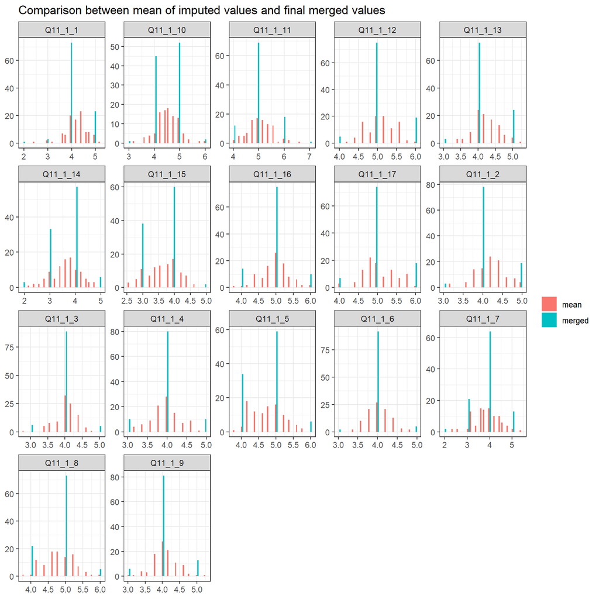

```r
library(sjmisc)
mice_mrg <- merge_imputations(
ic_to_impute,
tempData,
summary = c("hist" ),
filter = NULL
)
mice_mrg
```

Printing the merged of all 5 imputed data set

```r
head( mice_mrg$data, 20 ) %>% datatable(rownames = TRUE, filter="top", options = list(pageLength = 10, scrollX=T))
```

|  | Q11_1_1 | Q11_1_2 | Q11_1_3 | Q11_1_4 | Q11_1_5 | Q11_1_6 | Q11_1_7 | Q11_1_8 | Q11_1_9 | Q11_1_10 | Q11_1_11 | Q11_1_12 | Q11_1_13 | Q11_1_14 | Q11_1_15 | Q11_1_16 | Q11_1_17 |
| --- | --- | --- | --- | --- | --- | --- | --- | --- | --- | --- | --- | --- | --- | --- | --- | --- | --- |
| 1 | 4 | 4 | 4 | 4 | 4 | 4 | 4 | 4 | 3 | 5 | 5 | 5 | 3 | 4 | 3 | 5 | 6 |
| 2 | 6 | 4 | 6 | 2 | 4 | 2 | 2 | 5 | 5 | 5 | 6 | 6 | 5 | 2 | 2 | 6 | 6 |
| 3 | 5 | 6 | 5 | 5 | 4 | 5 | 6 | 5 | 5 | 4 | 6 | 5 | 4 | 6 | 5 | 6 | 6 |
| 4 | 4 | 4 | 4 | 4 | 5 | 4 | 2 | 5 | 4 | 4 | 6 | 5 | 4 | 5 | 4 | 5 | 6 |
| 5 | 4 | 4 | 4 | 4 | 4 | 4 | 4 | 4 | 4 | 4 | 4 | 4 | 4 | 4 | 4 | 4 | 4 |
| 6 | 2 | 3 | 3 | 3 | 4 | 3 | 4 | 3 | 4 | 4 | 5 | 4 | 4 | 2 | 2 | 4 | 4 |
| 7 | 4 | 4 | 4 | 4 | 5 | 4 | 3 | 5 | 5 | 4 | 4 | 5 | 4 | 3 | 4 | 5 | 5 |
| 8 | 4 | 4 | 4 | 4 | 4 | 4 | 4 | 4 | 4 | 4 | 4 | 4 | 4 | 4 | 4 | 4 | 4 |
| 9 | 4 | 5 | 4 | 5 | 5 | 4 | 4 | 5 | 4 | 5 | 7 | 6 | 5 | 4 | 4 | 5 | 5 |
| 10 | 5 | 4 | 4 | 4 | 5 | 4 | 5 | 5 | 4 | 5 | 5 | 5 | 5 | 4 | 4 | 5 | 5 |

[output cut: 10 more lines]

## 2.5 Comparing the imputed and original data sets statistically

The t-test is done to compare the means and variance of the imputed Q11s and the original subset.

|  | fs n | fs micerf n | fs mean | micerf mean | p-value |
| --- | --- | --- | --- | --- | --- |
| Q11_1_1 | 254 | 354 | 4.15 | 4.16 | 0.94 |
| Q11_1_2 | 254 | 354 | 4.17 | 4.17 | 0.97 |
| Q11_1_3 | 254 | 354 | 4.07 | 4.05 | 0.83 |
| Q11_1_4 | 254 | 354 | 3.93 | 3.95 | 0.85 |
| Q11_1_5 | 255 | 354 | 4.58 | 4.62 | 0.75 |
| Q11_1_6 | 255 | 354 | 4.04 | 4.04 | 0.97 |
| Q11_1_7 | 254 | 354 | 3.76 | 3.79 | 0.78 |
| Q11_1_8 | 254 | 354 | 4.64 | 4.69 | 0.65 |
| Q11_1_9 | 254 | 354 | 4.11 | 4.10 | 0.91 |
| Q11_1_10 | 254 | 354 | 4.45 | 4.48 | 0.80 |
| Q11_1_11 | 254 | 354 | 4.83 | 4.90 | 0.52 |
| Q11_1_12 | 255 | 354 | 4.78 | 4.88 | 0.37 |
| Q11_1_13 | 254 | 354 | 4.26 | 4.25 | 0.89 |
| Q11_1_14 | 255 | 354 | 3.59 | 3.61 | 0.85 |
| Q11_1_15 | 254 | 354 | 3.47 | 3.52 | 0.66 |
| Q11_1_16 | 255 | 354 | 4.77 | 4.82 | 0.65 |
| Q11_1_17 | 255 | 354 | 4.70 | 4.81 | 0.33 |

Comparing variances

|  | fs var | micerf var | p-value |
| --- | --- | --- | --- |
| Q11_1_1 | 2.34 | 1.75 | 0.01 |
| Q11_1_2 | 2.02 | 1.50 | 0.01 |
| Q11_1_3 | 2.11 | 1.54 | 0.01 |
| Q11_1_4 | 2.18 | 1.62 | 0.01 |
| Q11_1_5 | 2.18 | 1.66 | 0.02 |
| Q11_1_6 | 2.08 | 1.52 | 0.01 |
| Q11_1_7 | 2.65 | 2.02 | 0.02 |
| Q11_1_8 | 2.28 | 1.71 | 0.01 |
| Q11_1_9 | 1.95 | 1.45 | 0.01 |
| Q11_1_10 | 2.07 | 1.58 | 0.02 |
| Q11_1_11 | 1.93 | 1.49 | 0.03 |
| Q11_1_12 | 2.04 | 1.56 | 0.02 |
| Q11_1_13 | 1.85 | 1.39 | 0.01 |
| Q11_1_14 | 2.31 | 1.78 | 0.02 |
| Q11_1_15 | 1.94 | 1.47 | 0.02 |
| Q11_1_16 | 2.14 | 1.61 | 0.01 |
| Q11_1_17 | 2.35 | 1.79 | 0.02 |

By looking at the p-value and comparing them to our confidence interval of 95%. Imputation does well in the means but rather poorly in the variance. In the variance table, many of the seventeen questions have a p-value under the 0.05 limit. Evidently the merge-of-five imputations decreases the variance too much and has statistically significant difference with the original subset in terms of variance.  
This was surprising to me therefore I looked at each of the 5 imputed data sets to see how they perform in terms of variance.

|  | fs n | fs micerf n | fs mean | micerf mean | p-value |
| --- | --- | --- | --- | --- | --- |
| Q11_1_1 | 254 | 354 | 4.15 | 4.14 | 0.95 |
| Q11_1_2 | 254 | 354 | 4.17 | 4.16 | 0.93 |
| Q11_1_3 | 254 | 354 | 4.07 | 4.06 | 0.89 |
| Q11_1_4 | 254 | 354 | 3.93 | 3.91 | 0.87 |
| Q11_1_5 | 255 | 354 | 4.58 | 4.62 | 0.75 |
| Q11_1_6 | 255 | 354 | 4.04 | 4.04 | 0.97 |
| Q11_1_7 | 254 | 354 | 3.76 | 3.76 | 0.99 |
| Q11_1_8 | 254 | 354 | 4.64 | 4.71 | 0.59 |
| Q11_1_9 | 254 | 354 | 4.11 | 4.12 | 0.93 |
| Q11_1_10 | 254 | 354 | 4.45 | 4.47 | 0.88 |
| Q11_1_11 | 254 | 354 | 4.83 | 4.88 | 0.69 |
| Q11_1_12 | 255 | 354 | 4.78 | 4.88 | 0.41 |
| Q11_1_13 | 254 | 354 | 4.26 | 4.23 | 0.79 |
| Q11_1_14 | 255 | 354 | 3.59 | 3.55 | 0.74 |
| Q11_1_15 | 254 | 354 | 3.47 | 3.47 | 0.98 |
| Q11_1_16 | 255 | 354 | 4.77 | 4.82 | 0.69 |
| Q11_1_17 | 255 | 354 | 4.70 | 4.84 | 0.26 |

Comparing variances

|  | fs var | micerf var | p-value |
| --- | --- | --- | --- |
| Q11_1_1 | 2.34 | 1.88 | 0.06 |
| Q11_1_2 | 2.02 | 1.64 | 0.07 |
| Q11_1_3 | 2.11 | 1.68 | 0.05 |
| Q11_1_4 | 2.18 | 1.78 | 0.08 |
| Q11_1_5 | 2.18 | 1.89 | 0.22 |
| Q11_1_6 | 2.08 | 1.61 | 0.03 |
| Q11_1_7 | 2.65 | 2.55 | 0.72 |
| Q11_1_8 | 2.28 | 1.92 | 0.14 |
| Q11_1_9 | 1.95 | 1.56 | 0.05 |
| Q11_1_10 | 2.07 | 1.74 | 0.13 |
| Q11_1_11 | 1.93 | 1.72 | 0.33 |
| Q11_1_12 | 2.04 | 1.74 | 0.17 |
| Q11_1_13 | 1.85 | 1.52 | 0.09 |
| Q11_1_14 | 2.31 | 2.08 | 0.35 |
| Q11_1_15 | 1.94 | 1.75 | 0.36 |
| Q11_1_16 | 2.14 | 1.85 | 0.22 |
| Q11_1_17 | 2.35 | 2.02 | 0.19 |

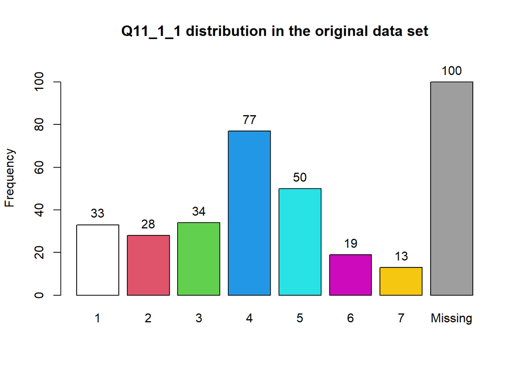

```
ic_to_impute[i] :
        Frequency   %(NA+)   %(NA-)
1              33      9.3     13.0
2              28      7.9     11.0
3              34      9.6     13.4
4              77     21.8     30.3
5              50     14.1     19.7
6              19      5.4      7.5
7              13      3.7      5.1
<NA>          100     28.2      0.0
  Total       354    100.0    100.0
```

```r
pacman::p_load(epiDisplay)
i = q11_1[7]
tab1(ic_to_impute[i], main = "Q11_1_1 distribution in the original data set" )
```

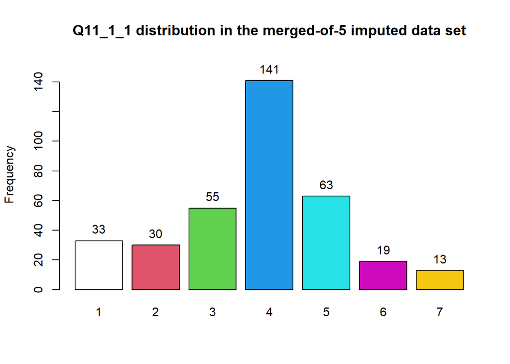

```
mice_mrg$data[i] :
        Frequency Percent Cum. percent
1              33     9.3          9.3
2              30     8.5         17.8
3              55    15.5         33.3
4             141    39.8         73.2
5              63    17.8         91.0
6              19     5.4         96.3
7              13     3.7        100.0
  Total       354   100.0        100.0
```

```r
tab1(mice_mrg$data[i], main = "Q11_1_1 distribution in the merged-of-5 imputed data set" )
```

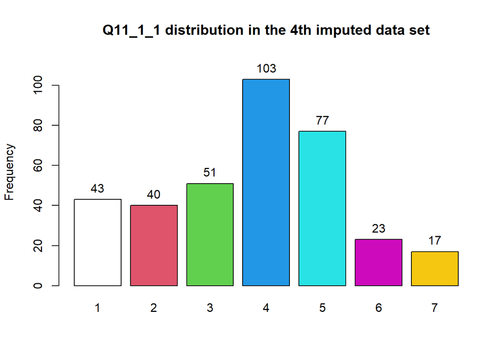

```
compData[i] :
        Frequency Percent Cum. percent
1              43    12.1         12.1
2              40    11.3         23.4
3              51    14.4         37.9
4             103    29.1         66.9
5              77    21.8         88.7
6              23     6.5         95.2
7              17     4.8        100.0
  Total       354   100.0        100.0
```

```r
tab1(compData[i], main = "Q11_1_1 distribution in the 4th imputed data set")
```

### 2.5.1 Combining the imputed data

```r
ic_sub_2[q11_1] <- compData
ic_sub_2 %>%  datatable( rownames = TRUE, filter="top", caption = "The imputed and complete data set", options = list(pageLength = 10, scrollX=T))
```

|  | ID | S7_1 | S8_1 | Q1_1 | Q2_1 | Q3_1 | Q11_1_1 | Q11_1_2 | Q11_1_3 | Q11_1_4 | Q11_1_5 | Q11_1_6 | Q11_1_7 | Q11_1_8 | Q11_1_9 | Q11_1_10 | Q11_1_11 | Q11_1_12 | Q11_1_13 | Q11_1_14 | Q11_1_15 | Q11_1_16 | Q11_1_17 | D1 | D2 | D3 | D4 | D5 | D6 | … |
| --- | --- | --- | --- | --- | --- | --- | --- | --- | --- | --- | --- | --- | --- | --- | --- | --- | --- | --- | --- | --- | --- | --- | --- | --- | --- | --- | --- | --- | --- | --- |
| 1 | 10834603 | 1 | 0 |  |  |  | 4 | 4 | 4 | 4 | 4 | 3 | 3 | 5 | 4 | 5 | 4 | 2 | 3 | 4 | 1 | 7 | 6 | 1 | 4 | 3 | 2 | 3 | 6 | … |
| 2 | 10834607 | 1 | 0 |  |  |  | 6 | 4 | 6 | 2 | 4 | 2 | 2 | 5 | 5 | 5 | 6 | 6 | 5 | 2 | 2 | 6 | 6 | 2 | 5 | 3 | 2 | 3 | 6 | … |
| 3 | 10834627 | 1 | 0 |  |  |  | 5 | 6 | 5 | 5 | 4 | 5 | 6 | 5 | 5 | 4 | 6 | 5 | 4 | 6 | 5 | 6 | 6 | 2 | 7 | 6 | 2 | 1 | 3 | … |
| 4 | 10834662 | 1 | 0 |  |  |  | 4 | 4 | 4 | 4 | 4 | 4 | 1 | 3 | 5 | 4 | 4 | 4 | 4 | 4 | 4 | 4 | 4 | 2 | 7 | 2 | 2 | 2 | 6 | … |
| 5 | 10834679 | 1 | 0 |  |  |  | 4 | 4 | 4 | 4 | 4 | 4 | 4 | 4 | 4 | 4 | 4 | 4 | 4 | 4 | 4 | 4 | 4 | 1 | 3 | 3 | 2 | 2 | 3 | … |
| 6 | 10834722 | 1 | 0 |  |  |  | 2 | 3 | 3 | 3 | 4 | 3 | 4 | 3 | 4 | 4 | 5 | 4 | 4 | 2 | 2 | 4 | 4 | 1 | 7 | 5 | 2 | 2 | 4 | … |
| 7 | 10834727 | 1 | 0 |  |  |  | 4 | 4 | 4 | 4 | 4 | 4 | 4 | 5 | 4 | 4 | 4 | 4 | 4 | 4 | 7 | 4 | 5 | 2 | 7 | 3 | 2 | 2 | 1 | … |
| 8 | 10834844 | 1 | 0 |  |  |  | 4 | 4 | 4 | 4 | 4 | 4 | 4 | 4 | 4 | 4 | 4 | 4 | 4 | 4 | 4 | 4 | 4 | 2 | 4 | 2 | 1 | 3 | 3 | … |
| 9 | 10834872 | 1 | 0 |  |  |  | 2 | 4 | 4 | 4 | 4 | 4 | 4 | 4 | 4 | 5 | 7 | 5 | 5 | 4 | 4 | 5 | 5 | 2 | 3 | 2 | 2 | 2 | 5 | … |
| 10 | 10834924 | 1 | 0 |  |  |  | 6 | 4 | 4 | 2 | 5 | 4 | 3 | 4 | 2 | 6 | 6 | 5 | 6 | 4 | 3 | 3 | 6 | 1 | 5 | 3 | 2 | 3 | 6 | … |

[output cut: 344 more lines]

## 2.6 Renaming the variables

The variables in the final subset of the ice cream data are renamed to make further analysis easier.

```r
demo_names <- c("Gender", "Age", "Marital", "Children_less_18", "Household_size", "Education", "Employment", "Ethnicity",
                "Household_income", "Residence_state")
names(ic_sub_2) <- c(c("ID", "Heard_of_brand", "Purchased_last6mo", "Satisfaction", "Buying_likelihood", "Recommend_likelihood",
                     "is_relaxing", "is_wholesome", "is_fun",
                     "is_exciting","is_premium_quality", "is_memorable", "is_treat", "is_good_for_regular",
                     "is_interesting", "taste_better_other_brands", "has_many_flavors", "is_enjoyable", "has_best_value/price",
                     "is_organic", "is_low_cal", "is_great_for_family", "is_great_for_guests") , demo_names)

ic_sub_2 %>%  datatable( rownames = TRUE, filter="top", options = list(pageLength = 10, scrollX=T))
```

|  | ID | Heard_of_brand | Purchased_last6mo | Satisfaction | Buying_likelihood | Recommend_likelihood | is_relaxing | is_wholesome | is_fun | is_exciting | is_premium_quality | is_memorable | is_treat | is_good_for_regular | is_interesting | taste_better_other_brands | has_many_flavors | is_enjoyable | has_best_value/price | is_organic | is_low_cal | is_great_for_family | is_great_for_guests | Gender | Age | Marital | Children_less_18 | Household_size | Education | … |
| --- | --- | --- | --- | --- | --- | --- | --- | --- | --- | --- | --- | --- | --- | --- | --- | --- | --- | --- | --- | --- | --- | --- | --- | --- | --- | --- | --- | --- | --- | --- |
| 1 | 10834603 | 1 | 0 |  |  |  | 4 | 4 | 4 | 4 | 4 | 3 | 3 | 5 | 4 | 5 | 4 | 2 | 3 | 4 | 1 | 7 | 6 | 1 | 4 | 3 | 2 | 3 | 6 | … |
| 2 | 10834607 | 1 | 0 |  |  |  | 6 | 4 | 6 | 2 | 4 | 2 | 2 | 5 | 5 | 5 | 6 | 6 | 5 | 2 | 2 | 6 | 6 | 2 | 5 | 3 | 2 | 3 | 6 | … |
| 3 | 10834627 | 1 | 0 |  |  |  | 5 | 6 | 5 | 5 | 4 | 5 | 6 | 5 | 5 | 4 | 6 | 5 | 4 | 6 | 5 | 6 | 6 | 2 | 7 | 6 | 2 | 1 | 3 | … |
| 4 | 10834662 | 1 | 0 |  |  |  | 4 | 4 | 4 | 4 | 4 | 4 | 1 | 3 | 5 | 4 | 4 | 4 | 4 | 4 | 4 | 4 | 4 | 2 | 7 | 2 | 2 | 2 | 6 | … |
| 5 | 10834679 | 1 | 0 |  |  |  | 4 | 4 | 4 | 4 | 4 | 4 | 4 | 4 | 4 | 4 | 4 | 4 | 4 | 4 | 4 | 4 | 4 | 1 | 3 | 3 | 2 | 2 | 3 | … |
| 6 | 10834722 | 1 | 0 |  |  |  | 2 | 3 | 3 | 3 | 4 | 3 | 4 | 3 | 4 | 4 | 5 | 4 | 4 | 2 | 2 | 4 | 4 | 1 | 7 | 5 | 2 | 2 | 4 | … |
| 7 | 10834727 | 1 | 0 |  |  |  | 4 | 4 | 4 | 4 | 4 | 4 | 4 | 5 | 4 | 4 | 4 | 4 | 4 | 4 | 7 | 4 | 5 | 2 | 7 | 3 | 2 | 2 | 1 | … |
| 8 | 10834844 | 1 | 0 |  |  |  | 4 | 4 | 4 | 4 | 4 | 4 | 4 | 4 | 4 | 4 | 4 | 4 | 4 | 4 | 4 | 4 | 4 | 2 | 4 | 2 | 1 | 3 | 3 | … |
| 9 | 10834872 | 1 | 0 |  |  |  | 2 | 4 | 4 | 4 | 4 | 4 | 4 | 4 | 4 | 5 | 7 | 5 | 5 | 4 | 4 | 5 | 5 | 2 | 3 | 2 | 2 | 2 | 5 | … |
| 10 | 10834924 | 1 | 0 |  |  |  | 6 | 4 | 4 | 2 | 5 | 4 | 3 | 4 | 2 | 6 | 6 | 5 | 6 | 4 | 3 | 3 | 6 | 1 | 5 | 3 | 2 | 3 | 6 | … |

[output cut: 344 more lines]

## 2.7 Recoding the demographic variables

Now it’s time to recode the values of different variables to a more meaningful format. Let’s first look at the demographic variables and see their current values.

```r
library(wrapr)
tt<- function(x) { table( x,  useNA = "ifany" ) }
24:33 %.>% ( function(x) { sapply( ic_sub_2[, (x)], tt ) } )  (.)
```

```
$Gender
x
  1   2
127 227

$Age
x
 2  3  4  5  6  7
18 75 49 60 58 94

$Marital
x
  1   2   3   4   5   6   7
 71  36 185  43   2  14   3

$Children_less_18
x
  1   2
 61 293

$Household_size
x
  1   2   3   4   5   6   7  11
 73 177  60  31  10   1   1   1

$Education
x
  1   2   3   4   5   6
 20  10 114 110  28  72

$Employment
x
  1   2   3   4   5   6
159  35  16  23 101  20

$Ethnicity
x
  1   2   3   4   5   6
285  19  13  22   9   6

$Household_income
x
  1   2   3   4   5   6   7   8   9
126 106  43  16  16   7   5   1  34

$Residence_state
x
 1  2  3  4  5  6  7 10 11 12 13 14 15 16 17 18 19 20 21 22 23 24 25 26 27 28
 3  7  9  1 63  9  6  9  3  5  5 16  6  3  3  3  1  2  2  4 16  8  2  6  1  3
29 30 31 32 33 34 36 37 38 39 41 42 43 44 45 46 47 48 50
10  1  8  2  8  2 10  3 12 13  4  1  6 38  3  1  5 22  9
```

Now using different tools and the provided questionnaires, the following demographic variables are recoded and depicted in tables below.

```r
ic_sub_2$Gender <- ifelse( ic_sub_2$Gender == 1, "Male", "Female")
frq(ic_sub_2$Gender, out="v", show.na=TRUE, title= "Gender of the participants")
```

Gender of the participants

| val | label | frq | raw.prc | valid.prc | cum.prc |  |
| --- | --- | --- | --- | --- | --- | --- |
| Female |  | 227 | 64.12 | 64.12 | 64.12 |  |
| Male |  | 127 | 35.88 | 35.88 | 100 |  |
| NA | NA | 0 | 0 | NA | NA |  |
| total N=354 · valid N=354 · x̄=1.36 · σ=0.48 |  |  |  |  |  |  |

```r
ic_sub_2$Age <- recode_factor(ic_sub_2$Age,`1` = "Under 18",
                                          `2` = "18-24",
                                          `3` = "25-34",
                                          `4` = "35-44",
                                          `5` = "45-54",
                                          `6` = "55-64",
                                          `7` = "65 or older")
frq(ic_sub_2$Age, out="v", show.na=TRUE, title= "Age of the participants")
```

Age of the participants

| val | label | frq | raw.prc | valid.prc | cum.prc |  |
| --- | --- | --- | --- | --- | --- | --- |
| 18-24 |  | 18 | 5.08 | 5.08 | 5.08 |  |
| 25-34 |  | 75 | 21.19 | 21.19 | 26.27 |  |
| 35-44 |  | 49 | 13.84 | 13.84 | 40.11 |  |
| 45-54 |  | 60 | 16.95 | 16.95 | 57.06 |  |
| 55-64 |  | 58 | 16.38 | 16.38 | 73.45 |  |
| 65 or older |  | 94 | 26.55 | 26.55 | 100 |  |
| NA | NA | 0 | 0 | NA | NA |  |
| total N=354 · valid N=354 · x̄=3.98 · σ=1.64 |  |  |  |  |  |  |

```r
ic_sub_2$Marital <- recode_factor(ic_sub_2$Marital,`1` = "Single, not living with domestic partner",
                                          `2` = "Single, living with domestic partner",
                                          `3` = "Married",
                                          `4` = "Divorced",
                                          `5` = "Separated",
                                          `6` = "Widowed",
                                          `7` = "Prefer not to say")
frq(ic_sub_2$Marital, out="v",sort.frq = c("desc"), show.na=TRUE, title= "Marital status of the participants")
```

Marital status of the participants

| val | label | frq | raw.prc | valid.prc | cum.prc |  |
| --- | --- | --- | --- | --- | --- | --- |
| Married |  | 185 | 52.26 | 52.26 | 52.26 |  |
| Single, not living with domestic partner |  | 71 | 20.06 | 20.06 | 72.32 |  |
| Divorced |  | 43 | 12.15 | 12.15 | 84.46 |  |
| Single, living with domestic partner |  | 36 | 10.17 | 10.17 | 94.63 |  |
| Widowed |  | 14 | 3.95 | 3.95 | 98.59 |  |
| Prefer not to say |  | 3 | 0.85 | 0.85 | 99.44 |  |
| Separated |  | 2 | 0.56 | 0.56 | 100 |  |
| NA | NA | 0 | 0 | NA | NA |  |
| total N=354 · valid N=354 · x̄=2.78 · σ=1.22 |  |  |  |  |  |  |

```r
ic_sub_2$Children_less_18 <- ifelse(ic_sub_2$Children_less_18 == 1, "Yes", "No")
frq(ic_sub_2$Children_less_18, out="v", show.na=TRUE, title= "Does Participants have children under the age of 18 living with them")
```

Does Participants have children under the age of 18 living with them

| val | label | frq | raw.prc | valid.prc | cum.prc |  |
| --- | --- | --- | --- | --- | --- | --- |
| No |  | 293 | 82.77 | 82.77 | 82.77 |  |
| Yes |  | 61 | 17.23 | 17.23 | 100 |  |
| NA | NA | 0 | 0 | NA | NA |  |
| total N=354 · valid N=354 · x̄=1.17 · σ=0.38 |  |  |  |  |  |  |

No need to recode the household size as it is a numerical variable

```r
frq(ic_sub_2$Household_size, out="v", show.na=TRUE, title= "Number of people living in participants household")
```

Number of people living in participants household

| val | label | frq | raw.prc | valid.prc | cum.prc |  |
| --- | --- | --- | --- | --- | --- | --- |
| 1 |  | 73 | 20.62 | 20.62 | 20.62 |  |
| 2 |  | 177 | 50 | 50 | 70.62 |  |
| 3 |  | 60 | 16.95 | 16.95 | 87.57 |  |
| 4 |  | 31 | 8.76 | 8.76 | 96.33 |  |
| 5 |  | 10 | 2.82 | 2.82 | 99.15 |  |
| 6 |  | 1 | 0.28 | 0.28 | 99.44 |  |
| 7 |  | 1 | 0.28 | 0.28 | 99.72 |  |
| 11 |  | 1 | 0.28 | 0.28 | 100 |  |
| NA | NA | 0 | 0 | NA | NA |  |
| total N=354 · valid N=354 · x̄=2.27 · σ=1.12 |  |  |  |  |  |  |

```r
ic_sub_2$Education <- recode_factor(ic_sub_2$Education,`1` = "High school or less",
                                          `2` = "Trade/Technical school",
                                          `3` = "Some college or Associate's Degree",
                                          `4` = "Graduated College/Bachelor's Degree",
                                          `5` = "Attended Graduate School",
                                          `6` = "Advanced Degree (Master's, PhD.D.)")
frq(ic_sub_2$Education, out="v", show.na=TRUE, title= "Education of the participants")
```

Education of the participants

| val | label | frq | raw.prc | valid.prc | cum.prc |  |
| --- | --- | --- | --- | --- | --- | --- |
| High school or less |  | 20 | 5.65 | 5.65 | 5.65 |  |
| Trade/Technical school |  | 10 | 2.82 | 2.82 | 8.47 |  |
| Some college or Associate’s Degree |  | 114 | 32.2 | 32.2 | 40.68 |  |
| Graduated College/Bachelor’s Degree |  | 110 | 31.07 | 31.07 | 71.75 |  |
| Attended Graduate School |  | 28 | 7.91 | 7.91 | 79.66 |  |
| Advanced Degree (Master’s, PhD.D.) |  | 72 | 20.34 | 20.34 | 100 |  |
| NA | NA | 0 | 0 | NA | NA |  |
| total N=354 · valid N=354 · x̄=3.94 · σ=1.36 |  |  |  |  |  |  |

```r
ic_sub_2$Ethnicity <- recode_factor(ic_sub_2$Ethnicity,`1` = "High school or less",
                                          `2` = "Trade/Technical school",
                                          `3` = "Some college or Associate's Degree",
                                          `4` = "Graduated College/Bachelor's Degree",
                                          `5` = "Attended Graduate School",
                                          `6` = "Advanced Degree (Master's, PhD.D.)")
frq(ic_sub_2$Ethnicity, out="v", show.na=TRUE, title= "Education of the participants")
```

Education of the participants

| val | label | frq | raw.prc | valid.prc | cum.prc |  |
| --- | --- | --- | --- | --- | --- | --- |
| High school or less |  | 285 | 80.51 | 80.51 | 80.51 |  |
| Trade/Technical school |  | 19 | 5.37 | 5.37 | 85.88 |  |
| Some college or Associate’s Degree |  | 13 | 3.67 | 3.67 | 89.55 |  |
| Graduated College/Bachelor’s Degree |  | 22 | 6.21 | 6.21 | 95.76 |  |
| Attended Graduate School |  | 9 | 2.54 | 2.54 | 98.31 |  |
| Advanced Degree (Master’s, PhD.D.) |  | 6 | 1.69 | 1.69 | 100 |  |
| NA | NA | 0 | 0 | NA | NA |  |
| total N=354 · valid N=354 · x̄=1.50 · σ=1.16 |  |  |  |  |  |  |

```r
ic_sub_2$Employment <- recode_factor(ic_sub_2$Employment,`1` = "Employed full-time (30+ hrs)",
                                          `2` = "Employed part time",
                                          `3` = "Not Currently Employed",
                                          `4` = "Student",
                                          `5` = "Retired",
                                          `6` = "Homemaker")
frq(ic_sub_2$Employment, out="v", show.na=TRUE, title= "Education of the participants")
```

Education of the participants

| val | label | frq | raw.prc | valid.prc | cum.prc |  |
| --- | --- | --- | --- | --- | --- | --- |
| Employed full-time (30+ hrs) |  | 159 | 44.92 | 44.92 | 44.92 |  |
| Employed part time |  | 35 | 9.89 | 9.89 | 54.8 |  |
| Not Currently Employed |  | 16 | 4.52 | 4.52 | 59.32 |  |
| Student |  | 23 | 6.5 | 6.5 | 65.82 |  |
| Retired |  | 101 | 28.53 | 28.53 | 94.35 |  |
| Homemaker |  | 20 | 5.65 | 5.65 | 100 |  |
| NA | NA | 0 | 0 | NA | NA |  |
| total N=354 · valid N=354 · x̄=2.81 · σ=1.89 |  |  |  |  |  |  |

```r
ic_sub_2$Household_income <- recode_factor(ic_sub_2$Household_income,`1` = "under $50,000",
                                          `2` = "$50,000 just under $75,000",
                                          `3` = "$75,000 just under $100,000",
                                          `4` = "$100,000 just under $125,000",
                                          `5` = "$125,000 just under $150,000",
                                          `6` = "$150,000 just under $175,000",
                                          `7` = "$175,000 just under $200,000",
                                          `8` = "$200,000 or more",
                                          `9` = "Prefer not to say")
frq(ic_sub_2$Household_income, out="v", show.na=TRUE, title= "Household income of the participants")
```

Household income of the participants

| val | label | frq | raw.prc | valid.prc | cum.prc |  |
| --- | --- | --- | --- | --- | --- | --- |
| under $50,000 |  | 126 | 35.59 | 35.59 | 35.59 |  |
| $50,000 just under $75,000 |  | 106 | 29.94 | 29.94 | 65.54 |  |
| $75,000 just under $100,000 |  | 43 | 12.15 | 12.15 | 77.68 |  |
| $100,000 just under $125,000 |  | 16 | 4.52 | 4.52 | 82.2 |  |
| $125,000 just under $150,000 |  | 16 | 4.52 | 4.52 | 86.72 |  |
| $150,000 just under $175,000 |  | 7 | 1.98 | 1.98 | 88.7 |  |
| $175,000 just under $200,000 |  | 5 | 1.41 | 1.41 | 90.11 |  |
| $200,000 or more |  | 1 | 0.28 | 0.28 | 90.4 |  |
| Prefer not to say |  | 34 | 9.6 | 9.6 | 100 |  |
| NA | NA | 0 | 0 | NA | NA |  |
| total N=354 · valid N=354 · x̄=2.83 · σ=2.42 |  |  |  |  |  |  |

The states were assigned a number, the actual name is not evident. There are a total of 50 states.

```r
frq(ic_sub_2$Residence_state, out="v", show.na=TRUE, title= "Residence state of the participants")
```

Residence state of the participants

| val | label | frq | raw.prc | valid.prc | cum.prc |  |
| --- | --- | --- | --- | --- | --- | --- |
| 1 |  | 3 | 0.85 | 0.85 | 0.85 |  |
| 2 |  | 7 | 1.98 | 1.98 | 2.82 |  |
| 3 |  | 9 | 2.54 | 2.54 | 5.37 |  |
| 4 |  | 1 | 0.28 | 0.28 | 5.65 |  |
| 5 |  | 63 | 17.8 | 17.8 | 23.45 |  |
| 6 |  | 9 | 2.54 | 2.54 | 25.99 |  |
| 7 |  | 6 | 1.69 | 1.69 | 27.68 |  |
| 10 |  | 9 | 2.54 | 2.54 | 30.23 |  |
| 11 |  | 3 | 0.85 | 0.85 | 31.07 |  |
| 12 |  | 5 | 1.41 | 1.41 | 32.49 |  |
| 13 |  | 5 | 1.41 | 1.41 | 33.9 |  |
| 14 |  | 16 | 4.52 | 4.52 | 38.42 |  |
| 15 |  | 6 | 1.69 | 1.69 | 40.11 |  |
| 16 |  | 3 | 0.85 | 0.85 | 40.96 |  |
| 17 |  | 3 | 0.85 | 0.85 | 41.81 |  |
| 18 |  | 3 | 0.85 | 0.85 | 42.66 |  |
| 19 |  | 1 | 0.28 | 0.28 | 42.94 |  |
| 20 |  | 2 | 0.56 | 0.56 | 43.5 |  |
| 21 |  | 2 | 0.56 | 0.56 | 44.07 |  |
| 22 |  | 4 | 1.13 | 1.13 | 45.2 |  |
| 23 |  | 16 | 4.52 | 4.52 | 49.72 |  |
| 24 |  | 8 | 2.26 | 2.26 | 51.98 |  |
| 25 |  | 2 | 0.56 | 0.56 | 52.54 |  |
| 26 |  | 6 | 1.69 | 1.69 | 54.24 |  |
| 27 |  | 1 | 0.28 | 0.28 | 54.52 |  |
| 28 |  | 3 | 0.85 | 0.85 | 55.37 |  |
| 29 |  | 10 | 2.82 | 2.82 | 58.19 |  |
| 30 |  | 1 | 0.28 | 0.28 | 58.47 |  |
| 31 |  | 8 | 2.26 | 2.26 | 60.73 |  |
| 32 |  | 2 | 0.56 | 0.56 | 61.3 |  |
| 33 |  | 8 | 2.26 | 2.26 | 63.56 |  |
| 34 |  | 2 | 0.56 | 0.56 | 64.12 |  |
| 36 |  | 10 | 2.82 | 2.82 | 66.95 |  |
| 37 |  | 3 | 0.85 | 0.85 | 67.8 |  |
| 38 |  | 12 | 3.39 | 3.39 | 71.19 |  |
| 39 |  | 13 | 3.67 | 3.67 | 74.86 |  |
| 41 |  | 4 | 1.13 | 1.13 | 75.99 |  |
| 42 |  | 1 | 0.28 | 0.28 | 76.27 |  |
| 43 |  | 6 | 1.69 | 1.69 | 77.97 |  |
| 44 |  | 38 | 10.73 | 10.73 | 88.7 |  |
| 45 |  | 3 | 0.85 | 0.85 | 89.55 |  |
| 46 |  | 1 | 0.28 | 0.28 | 89.83 |  |
| 47 |  | 5 | 1.41 | 1.41 | 91.24 |  |
| 48 |  | 22 | 6.21 | 6.21 | 97.46 |  |
| 50 |  | 9 | 2.54 | 2.54 | 100 |  |
| NA | NA | 0 | 0 | NA | NA |  |
| total N=354 · valid N=354 · x̄=24.56 · σ=16.31 |  |  |  |  |  |  |

## 2.8 Recoding the Perception and Attitude variables

Let’s look at the current values of these variables. Which are Q1-Q3 and Q11_1_1 to Q11_1_17

```r
frq(ic_sub_2$Satisfaction, out="v", show.na=TRUE, title= "Different values in the Behavioral questions")
```

Different values in the Behavioral questions

| val | label | frq | raw.prc | valid.prc | cum.prc |  |
| --- | --- | --- | --- | --- | --- | --- |
| 1 |  | 1 | 0.28 | 0.83 | 0.83 |  |
| 2 |  | 1 | 0.28 | 0.83 | 1.67 |  |
| 4 |  | 7 | 1.98 | 5.83 | 7.5 |  |
| 5 |  | 22 | 6.21 | 18.33 | 25.83 |  |
| 6 |  | 43 | 12.15 | 35.83 | 61.67 |  |
| 7 |  | 46 | 12.99 | 38.33 | 100 |  |
| NA | NA | 234 | 66.1 | NA | NA |  |
| total N=354 · valid N=120 · x̄=6.01 · σ=1.07 |  |  |  |  |  |  |

The values span from 1 to 7 therefore we use a 7 Point Likert Scale to recode them. “1” being Extremely negative and “7” the extremely positive.

As these variables would be used for further analyses, to save their natural numerical format, the recoded categorical columns would be appended to end of data set.

```r
ic_sub_2$Satisfaction_cat <- dplyr::recode_factor(ic_sub_2$Satisfaction,
                                                  `1` = "Extremely Dissatisfied",
                                                  `2` = "Dissatisfied",
                                                  `3` = "Somewhat Dissatisfied",
                                                  `4` = "Neither Dissatisfied nor Satisfied",
                                                  `5` = "Somewhat Satisfied",
                                                  `6` = "Satisfied",
                                                  `7` = "Extremely Satisfied"
                       )
y <- c("Extremely Satisfied","Satisfied", "Somewhat Satisfied", "Neither Dissatisfied nor Satisfied",
  "Somewhat Dissatisfied", "Dissatisfied", "Extremely Dissatisfied")

ic_sub_2$Satisfaction_cat <- factor(ic_sub_2$Satisfaction_cat, levels = y )
frq(ic_sub_2$Satisfaction_cat, out="v", show.na=TRUE, title= "How satisfied with Ice Cream Brand")
```

How satisfied with Ice Cream Brand

| val | label | frq | raw.prc | valid.prc | cum.prc |  |
| --- | --- | --- | --- | --- | --- | --- |
| Extremely Satisfied |  | 46 | 12.99 | 38.33 | 38.33 |  |
| Satisfied |  | 43 | 12.15 | 35.83 | 74.17 |  |
| Somewhat Satisfied |  | 22 | 6.21 | 18.33 | 92.5 |  |
| Neither Dissatisfied nor Satisfied |  | 7 | 1.98 | 5.83 | 98.33 |  |
| Somewhat Dissatisfied |  | 0 | 0 | 0 | 98.33 |  |
| Dissatisfied |  | 1 | 0.28 | 0.83 | 99.17 |  |
| Extremely Dissatisfied |  | 1 | 0.28 | 0.83 | 100 |  |
| NA | NA | 234 | 66.1 | NA | NA |  |
| total N=354 · valid N=120 · x̄=1.99 · σ=1.07 |  |  |  |  |  |  |

Now we look at Q2 or Buying_likelihood variable in the data set.

```r
ic_sub_2$Buying_likelihood_cat <- dplyr::recode_factor(ic_sub_2$Buying_likelihood,
                                                  `1` = "Not at all Likely to purchase again",
                                                  `2` = "Not Likely to purchase again",
                                                  `3` = "Not Somewhat  Likely to purchase again",
                                                  `4` = "Neither Likely nor Unlikely to purchase again",
                                                  `5` = "Somewhat Likely to purchase again",
                                                  `6` = "Likely to purchase again",
                                                  `7` = "Extremely Likely to purchase again"
                       )

y <- c("Extremely Likely to purchase again", "Likely to purchase again",  "Somewhat Likely to purchase again",
  "Neither Likely nor Unlikely to purchase again",  "Somewhat Not Likely to purchase again",
  "Not Likely to purchase again",  "Not at all Likely to purchase again")

ic_sub_2$Buying_likelihood_cat <- factor(ic_sub_2$Buying_likelihood_cat, levels = y )
frq(ic_sub_2$Buying_likelihood_cat, out="v", show.na=TRUE, title= "How Likely to purchase brand again")
```

How Likely to purchase brand again

| val | label | frq | raw.prc | valid.prc | cum.prc |  |
| --- | --- | --- | --- | --- | --- | --- |
| Extremely Likely to purchase again |  | 74 | 20.9 | 61.67 | 61.67 |  |
| Likely to purchase again |  | 29 | 8.19 | 24.17 | 85.83 |  |
| Somewhat Likely to purchase again |  | 11 | 3.11 | 9.17 | 95 |  |
| Neither Likely nor Unlikely to purchase again |  | 6 | 1.69 | 5 | 100 |  |
| Somewhat Not Likely to purchase again |  | 0 | 0 | 0 | 100 |  |
| Not Likely to purchase again |  | 0 | 0 | 0 | 100 |  |
| Not at all Likely to purchase again |  | 0 | 0 | 0 | 100 |  |
| NA | NA | 234 | 66.1 | NA | NA |  |
| total N=354 · valid N=120 · x̄=1.57 · σ=0.86 |  |  |  |  |  |  |

Now we look at Q3 or Recommendation likelihood variable in the data set.

```r
ic_sub_2$Recommend_likehood_cat <- dplyr::recode_factor(ic_sub_2$Recommend_likelihood,
                                                  `1` = "Not at all Likely to recommend",
                                                  `2` = "Not Likely to recommend",
                                                  `3` = "Not Somewhat  Likely to recommend",
                                                  `4` = "Neither Likely nor Unlikely to recommend",
                                                  `5` = "Somewhat Likely to recommend",
                                                  `6` = "Likely to recommend",
                                                  `7` = "Extremely Likely to recommend"
                       )

y <- c("Extremely Likely to recommend", "Likely to recommend",  "Somewhat Likely to recommend",
  "Neither Likely nor Unlikely to recommend",  "Somewhat Not Likely to recommend",
  "Not Likely to recommend",  "Not at all Likely to recommend")

ic_sub_2$Recommend_likehood_cat <- factor(ic_sub_2$Recommend_likehood_cat, levels = y )
frq(ic_sub_2$Recommend_likehood_cat, out="v", show.na=TRUE, title= "How Likely to recommend brand again")
```

How Likely to recommend brand again

[output not shown]

### 2.8.1 Recoding the brand perception and opinion variables

All 17 variables in this area (Q_1_1 to Q_1_17) could be coded with the same format. Again for not losing their numerical for further analyses, they are recoded into new variables and added to the data set. First we make those new categorical variables and then recode them. Tables of 17 “recoded” perception questions of Dreyer’s brand appear next.

```r
library(forcats)

ftt <- function(x) { ordered( x, levels = c("1", "2", "3", "4", "5", "6", "7")) }
ic_sub_2[, 37:53] <- 7:24 %.>% ( function(x) { lapply( ic_sub_2[, (x)], ftt ) } )  (.)

rr <- function(x) { dplyr::recode_factor( x,
                                          `1` = "Does not describe at all",
                                          `2` = "Does not describe",
                                          `3` = "Not Somewhat does describe",
                                          `4` = "Neither does nor does not describe",
                                          `5` = "Somewhat does describe well",
                                          `6` = "Does describe well",
                                          `7` = "Describes extremely well"
) }
ic_sub_2[, 37:53] <- 37:53 %.>% ( function(x) { lapply( ic_sub_2[, (x)], rr ) } )  (.)


frq( fct_rev(ic_sub_2[,37]), out="v", show.na=TRUE, title= "is relaxing")
```

is relaxing

| val | label | frq | raw.prc | valid.prc | cum.prc |  |
| --- | --- | --- | --- | --- | --- | --- |
| Describes extremely well |  | 15 | 4.24 | 4.24 | 4.24 |  |
| Does describe well |  | 39 | 11.02 | 11.02 | 15.25 |  |
| Somewhat does describe well |  | 67 | 18.93 | 18.93 | 34.18 |  |
| Neither does nor does not describe |  | 157 | 44.35 | 44.35 | 78.53 |  |
| Not Somewhat does describe |  | 31 | 8.76 | 8.76 | 87.29 |  |
| Does not describe |  | 25 | 7.06 | 7.06 | 94.35 |  |
| Does not describe at all |  | 20 | 5.65 | 5.65 | 100 |  |
| NA | NA | 0 | 0 | NA | NA |  |
| total N=354 · valid N=354 · x̄=3.86 · σ=1.37 |  |  |  |  |  |  |

```r
frq( fct_rev(ic_sub_2[,38]), out="v", show.na=TRUE, title= "is wholesome" )
```

is wholesome

| val | label | frq | raw.prc | valid.prc | cum.prc |  |
| --- | --- | --- | --- | --- | --- | --- |
| Describes extremely well |  | 13 | 3.67 | 3.67 | 3.67 |  |
| Does describe well |  | 39 | 11.02 | 11.02 | 14.69 |  |
| Somewhat does describe well |  | 66 | 18.64 | 18.64 | 33.33 |  |
| Neither does nor does not describe |  | 161 | 45.48 | 45.48 | 78.81 |  |
| Not Somewhat does describe |  | 37 | 10.45 | 10.45 | 89.27 |  |
| Does not describe |  | 26 | 7.34 | 7.34 | 96.61 |  |
| Does not describe at all |  | 12 | 3.39 | 3.39 | 100 |  |
| NA | NA | 0 | 0 | NA | NA |  |
| total N=354 · valid N=354 · x̄=3.84 · σ=1.28 |  |  |  |  |  |  |

```r
frq( fct_rev(ic_sub_2[,39]), out="v", show.na=TRUE, title= "is fun"           )
```

is fun

| val | label | frq | raw.prc | valid.prc | cum.prc |  |
| --- | --- | --- | --- | --- | --- | --- |
| Describes extremely well |  | 14 | 3.95 | 3.95 | 3.95 |  |
| Does describe well |  | 28 | 7.91 | 7.91 | 11.86 |  |
| Somewhat does describe well |  | 57 | 16.1 | 16.1 | 27.97 |  |
| Neither does nor does not describe |  | 181 | 51.13 | 51.13 | 79.1 |  |
| Not Somewhat does describe |  | 37 | 10.45 | 10.45 | 89.55 |  |
| Does not describe |  | 14 | 3.95 | 3.95 | 93.5 |  |
| Does not describe at all |  | 23 | 6.5 | 6.5 | 100 |  |
| NA | NA | 0 | 0 | NA | NA |  |
| total N=354 · valid N=354 · x̄=3.94 · σ=1.30 |  |  |  |  |  |  |

```r
frq( fct_rev(ic_sub_2[,40]), out="v", show.na=TRUE, title= "is exciting"       )
```

is exciting

| val | label | frq | raw.prc | valid.prc | cum.prc |  |
| --- | --- | --- | --- | --- | --- | --- |
| Describes extremely well |  | 13 | 3.67 | 3.67 | 3.67 |  |
| Does describe well |  | 27 | 7.63 | 7.63 | 11.3 |  |
| Somewhat does describe well |  | 44 | 12.43 | 12.43 | 23.73 |  |
| Neither does nor does not describe |  | 176 | 49.72 | 49.72 | 73.45 |  |
| Not Somewhat does describe |  | 38 | 10.73 | 10.73 | 84.18 |  |
| Does not describe |  | 36 | 10.17 | 10.17 | 94.35 |  |
| Does not describe at all |  | 20 | 5.65 | 5.65 | 100 |  |
| NA | NA | 0 | 0 | NA | NA |  |
| total N=354 · valid N=354 · x̄=4.09 · σ=1.33 |  |  |  |  |  |  |

```r
frq( fct_rev(ic_sub_2[,41]), out="v", show.na=TRUE, title= "has premium quality")
```

has premium quality

| val | label | frq | raw.prc | valid.prc | cum.prc |  |
| --- | --- | --- | --- | --- | --- | --- |
| Describes extremely well |  | 31 | 8.76 | 8.76 | 8.76 |  |
| Does describe well |  | 71 | 20.06 | 20.06 | 28.81 |  |
| Somewhat does describe well |  | 70 | 19.77 | 19.77 | 48.59 |  |
| Neither does nor does not describe |  | 130 | 36.72 | 36.72 | 85.31 |  |
| Not Somewhat does describe |  | 29 | 8.19 | 8.19 | 93.5 |  |
| Does not describe |  | 13 | 3.67 | 3.67 | 97.18 |  |
| Does not describe at all |  | 10 | 2.82 | 2.82 | 100 |  |
| NA | NA | 0 | 0 | NA | NA |  |
| total N=354 · valid N=354 · x̄=3.38 · σ=1.37 |  |  |  |  |  |  |

```r
frq( fct_rev(ic_sub_2[,42]), out="v", show.na=TRUE, title= "is memorable"            )
```

is memorable

| val | label | frq | raw.prc | valid.prc | cum.prc |  |
| --- | --- | --- | --- | --- | --- | --- |
| Describes extremely well |  | 17 | 4.8 | 4.8 | 4.8 |  |
| Does describe well |  | 20 | 5.65 | 5.65 | 10.45 |  |
| Somewhat does describe well |  | 61 | 17.23 | 17.23 | 27.68 |  |
| Neither does nor does not describe |  | 171 | 48.31 | 48.31 | 75.99 |  |
| Not Somewhat does describe |  | 48 | 13.56 | 13.56 | 89.55 |  |
| Does not describe |  | 21 | 5.93 | 5.93 | 95.48 |  |
| Does not describe at all |  | 16 | 4.52 | 4.52 | 100 |  |
| NA | NA | 0 | 0 | NA | NA |  |
| total N=354 · valid N=354 · x̄=3.96 · σ=1.27 |  |  |  |  |  |  |

```r
frq( fct_rev(ic_sub_2[,43]), out="v", show.na=TRUE, title= "Bought as special treat but not regularly")
```

Bought as special treat but not regularly

| val | label | frq | raw.prc | valid.prc | cum.prc |  |
| --- | --- | --- | --- | --- | --- | --- |
| Describes extremely well |  | 17 | 4.8 | 4.8 | 4.8 |  |
| Does describe well |  | 23 | 6.5 | 6.5 | 11.3 |  |
| Somewhat does describe well |  | 77 | 21.75 | 21.75 | 33.05 |  |
| Neither does nor does not describe |  | 103 | 29.1 | 29.1 | 62.15 |  |
| Not Somewhat does describe |  | 51 | 14.41 | 14.41 | 76.55 |  |
| Does not describe |  | 40 | 11.3 | 11.3 | 87.85 |  |
| Does not describe at all |  | 43 | 12.15 | 12.15 | 100 |  |
| NA | NA | 0 | 0 | NA | NA |  |
| total N=354 · valid N=354 · x̄=4.24 · σ=1.60 |  |  |  |  |  |  |

```r
frq( fct_rev(ic_sub_2[,44]), out="v", show.na=TRUE, title= "is good for regular consumption")
```

is good for regular consumption

| val | label | frq | raw.prc | valid.prc | cum.prc |  |
| --- | --- | --- | --- | --- | --- | --- |
| Describes extremely well |  | 37 | 10.45 | 10.45 | 10.45 |  |
| Does describe well |  | 60 | 16.95 | 16.95 | 27.4 |  |
| Somewhat does describe well |  | 100 | 28.25 | 28.25 | 55.65 |  |
| Neither does nor does not describe |  | 113 | 31.92 | 31.92 | 87.57 |  |
| Not Somewhat does describe |  | 20 | 5.65 | 5.65 | 93.22 |  |
| Does not describe |  | 11 | 3.11 | 3.11 | 96.33 |  |
| Does not describe at all |  | 13 | 3.67 | 3.67 | 100 |  |
| NA | NA | 0 | 0 | NA | NA |  |
| total N=354 · valid N=354 · x̄=3.29 · σ=1.39 |  |  |  |  |  |  |

```r
frq( fct_rev(ic_sub_2[,45]), out="v", show.na=TRUE, title= "is interesting")
```

is interesting

| val | label | frq | raw.prc | valid.prc | cum.prc |  |
| --- | --- | --- | --- | --- | --- | --- |
| Describes extremely well |  | 13 | 3.67 | 3.67 | 3.67 |  |
| Does describe well |  | 32 | 9.04 | 9.04 | 12.71 |  |
| Somewhat does describe well |  | 62 | 17.51 | 17.51 | 30.23 |  |
| Neither does nor does not describe |  | 174 | 49.15 | 49.15 | 79.38 |  |
| Not Somewhat does describe |  | 41 | 11.58 | 11.58 | 90.96 |  |
| Does not describe |  | 16 | 4.52 | 4.52 | 95.48 |  |
| Does not describe at all |  | 16 | 4.52 | 4.52 | 100 |  |
| NA | NA | 0 | 0 | NA | NA |  |
| total N=354 · valid N=354 · x̄=3.88 · σ=1.25 |  |  |  |  |  |  |

```r
frq( fct_rev(ic_sub_2[,46]), out="v", show.na=TRUE, title= "Tastes better than other brands" )
```

Tastes better than other brands

| val | label | frq | raw.prc | valid.prc | cum.prc |  |
| --- | --- | --- | --- | --- | --- | --- |
| Describes extremely well |  | 24 | 6.78 | 6.78 | 6.78 |  |
| Does describe well |  | 51 | 14.41 | 14.41 | 21.19 |  |
| Somewhat does describe well |  | 85 | 24.01 | 24.01 | 45.2 |  |
| Neither does nor does not describe |  | 135 | 38.14 | 38.14 | 83.33 |  |
| Not Somewhat does describe |  | 35 | 9.89 | 9.89 | 93.22 |  |
| Does not describe |  | 13 | 3.67 | 3.67 | 96.89 |  |
| Does not describe at all |  | 11 | 3.11 | 3.11 | 100 |  |
| NA | NA | 0 | 0 | NA | NA |  |
| total N=354 · valid N=354 · x̄=3.53 · σ=1.32 |  |  |  |  |  |  |

```r
frq( fct_rev(ic_sub_2[,47]), out="v", show.na=TRUE, title= "Has many flavors")
```

Has many flavors

| val | label | frq | raw.prc | valid.prc | cum.prc |  |
| --- | --- | --- | --- | --- | --- | --- |
| Describes extremely well |  | 43 | 12.15 | 12.15 | 12.15 |  |
| Does describe well |  | 70 | 19.77 | 19.77 | 31.92 |  |
| Somewhat does describe well |  | 98 | 27.68 | 27.68 | 59.6 |  |
| Neither does nor does not describe |  | 109 | 30.79 | 30.79 | 90.4 |  |
| Not Somewhat does describe |  | 17 | 4.8 | 4.8 | 95.2 |  |
| Does not describe |  | 11 | 3.11 | 3.11 | 98.31 |  |
| Does not describe at all |  | 6 | 1.69 | 1.69 | 100 |  |
| NA | NA | 0 | 0 | NA | NA |  |
| total N=354 · valid N=354 · x̄=3.12 · σ=1.31 |  |  |  |  |  |  |

```r
frq( fct_rev(ic_sub_2[,48]), out="v", show.na=TRUE, title= "Is enjoyable"   )
```

Is enjoyable

| val | label | frq | raw.prc | valid.prc | cum.prc |  |
| --- | --- | --- | --- | --- | --- | --- |
| Describes extremely well |  | 36 | 10.17 | 10.17 | 10.17 |  |
| Does describe well |  | 82 | 23.16 | 23.16 | 33.33 |  |
| Somewhat does describe well |  | 102 | 28.81 | 28.81 | 62.15 |  |
| Neither does nor does not describe |  | 97 | 27.4 | 27.4 | 89.55 |  |
| Not Somewhat does describe |  | 21 | 5.93 | 5.93 | 95.48 |  |
| Does not describe |  | 6 | 1.69 | 1.69 | 97.18 |  |
| Does not describe at all |  | 10 | 2.82 | 2.82 | 100 |  |
| NA | NA | 0 | 0 | NA | NA |  |
| total N=354 · valid N=354 · x̄=3.12 · σ=1.32 |  |  |  |  |  |  |

```r
frq( fct_rev(ic_sub_2[,49]), out="v", show.na=TRUE, title= "Has best value for price"   )
```

Has best value for price

| val | label | frq | raw.prc | valid.prc | cum.prc |  |
| --- | --- | --- | --- | --- | --- | --- |
| Describes extremely well |  | 18 | 5.08 | 5.08 | 5.08 |  |
| Does describe well |  | 31 | 8.76 | 8.76 | 13.84 |  |
| Somewhat does describe well |  | 69 | 19.49 | 19.49 | 33.33 |  |
| Neither does nor does not describe |  | 170 | 48.02 | 48.02 | 81.36 |  |
| Not Somewhat does describe |  | 41 | 11.58 | 11.58 | 92.94 |  |
| Does not describe |  | 13 | 3.67 | 3.67 | 96.61 |  |
| Does not describe at all |  | 12 | 3.39 | 3.39 | 100 |  |
| NA | NA | 0 | 0 | NA | NA |  |
| total N=354 · valid N=354 · x̄=3.77 · σ=1.23 |  |  |  |  |  |  |

```r
frq( fct_rev(ic_sub_2[,50]), out="v", show.na=TRUE, title= "is natural/organic")
```

is natural/organic

| val | label | frq | raw.prc | valid.prc | cum.prc |  |
| --- | --- | --- | --- | --- | --- | --- |
| Describes extremely well |  | 8 | 2.26 | 2.26 | 2.26 |  |
| Does describe well |  | 18 | 5.08 | 5.08 | 7.34 |  |
| Somewhat does describe well |  | 45 | 12.71 | 12.71 | 20.06 |  |
| Neither does nor does not describe |  | 151 | 42.66 | 42.66 | 62.71 |  |
| Not Somewhat does describe |  | 42 | 11.86 | 11.86 | 74.58 |  |
| Does not describe |  | 47 | 13.28 | 13.28 | 87.85 |  |
| Does not describe at all |  | 43 | 12.15 | 12.15 | 100 |  |
| NA | NA | 0 | 0 | NA | NA |  |
| total N=354 · valid N=354 · x̄=4.45 · σ=1.44 |  |  |  |  |  |  |

```r
frq( fct_rev(ic_sub_2[,51]), out="v", show.na=TRUE, title= "is low calorie")
```

is low calorie

| val | label | frq | raw.prc | valid.prc | cum.prc |  |
| --- | --- | --- | --- | --- | --- | --- |
| Describes extremely well |  | 6 | 1.69 | 1.69 | 1.69 |  |
| Does describe well |  | 9 | 2.54 | 2.54 | 4.24 |  |
| Somewhat does describe well |  | 42 | 11.86 | 11.86 | 16.1 |  |
| Neither does nor does not describe |  | 153 | 43.22 | 43.22 | 59.32 |  |
| Not Somewhat does describe |  | 61 | 17.23 | 17.23 | 76.55 |  |
| Does not describe |  | 45 | 12.71 | 12.71 | 89.27 |  |
| Does not describe at all |  | 38 | 10.73 | 10.73 | 100 |  |
| NA | NA | 0 | 0 | NA | NA |  |
| total N=354 · valid N=354 · x̄=4.53 · σ=1.32 |  |  |  |  |  |  |

```r
frq( fct_rev(ic_sub_2[,52]), out="v", show.na=TRUE, title= "Great for whole family")
```

Great for whole family

| val | label | frq | raw.prc | valid.prc | cum.prc |  |
| --- | --- | --- | --- | --- | --- | --- |
| Describes extremely well |  | 44 | 12.43 | 12.43 | 12.43 |  |
| Does describe well |  | 69 | 19.49 | 19.49 | 31.92 |  |
| Somewhat does describe well |  | 85 | 24.01 | 24.01 | 55.93 |  |
| Neither does nor does not describe |  | 117 | 33.05 | 33.05 | 88.98 |  |
| Not Somewhat does describe |  | 22 | 6.21 | 6.21 | 95.2 |  |
| Does not describe |  | 8 | 2.26 | 2.26 | 97.46 |  |
| Does not describe at all |  | 9 | 2.54 | 2.54 | 100 |  |
| NA | NA | 0 | 0 | NA | NA |  |
| total N=354 · valid N=354 · x̄=3.18 · σ=1.36 |  |  |  |  |  |  |

```r
frq( fct_rev(ic_sub_2[,53]), out="v", show.na=TRUE, title= "Great for guests")
```

Great for guests

| val | label | frq | raw.prc | valid.prc | cum.prc |  |
| --- | --- | --- | --- | --- | --- | --- |
| Describes extremely well |  | 42 | 11.86 | 11.86 | 11.86 |  |
| Does describe well |  | 75 | 21.19 | 21.19 | 33.05 |  |
| Somewhat does describe well |  | 100 | 28.25 | 28.25 | 61.3 |  |
| Neither does nor does not describe |  | 94 | 26.55 | 26.55 | 87.85 |  |
| Not Somewhat does describe |  | 20 | 5.65 | 5.65 | 93.5 |  |
| Does not describe |  | 9 | 2.54 | 2.54 | 96.05 |  |
| Does not describe at all |  | 14 | 3.95 | 3.95 | 100 |  |
| NA | NA | 0 | 0 | NA | NA |  |
| total N=354 · valid N=354 · x̄=3.16 · σ=1.42 |  |  |  |  |  |  |

Changing the names of new categorical variables. Adding a suffix to imply their categorical format.

```r
q <- c("is_relaxing", "is_wholesome", "is_fun",
                     "is_exciting","is_premium_quality", "is_memorable", "is_treat", "is_good_for_regular",
                     "is_interesting", "taste_better_other_brands", "has_many_flavors", "is_enjoyable", "has_best_value/price",
                     "is_organic", "is_low_cal", "is_great_for_family", "is_great_for_guests")

colnames(ic_sub_2)[37:53] <- gsub("$", "_cat", q)
```

Recoding the Heard of brand and Purchased brands variables and checking the data.

```r
ic_sub_2$Heard_of_brand <- ifelse(ic_sub_2$Heard_of_brand ==1, 'yes', 'no')
ic_sub_2$Purchased_last6mo <- ifelse(ic_sub_2$Purchased_last6mo ==1, 'yes', 'no')
```

## 2.9 Saving the final data set

This recoded, imputed and filtered dataset is saved in your working directory by using the code below.

```r
write.csv(ic_sub_2, "./final_data.csv", row.names = FALSE)
```

# 3 Conclusion

The final data set is consisted of 354 observations and 53 variables. It includes the behavioural questions (Q1-Q3 and Q11) for the Dreyer’s brand and the demographic data of participants in both numerical and categorical format. The participants are people who have heard of Dreyer’s brand and have both purchased and not purchased the brand in the past 6 months. The variable names has been recoded to represent their natural meaning and ease further analyses. Further info about the cleaned version of data could be find in previous sections.

```r
ic_sub_2 %>%  datatable( rownames = TRUE, filter="top", options = list(pageLength = 5, scrollX=T))
```

|  | ID | Heard_of_brand | Purchased_last6mo | Satisfaction | Buying_likelihood | Recommend_likelihood | is_relaxing | is_wholesome | is_fun | is_exciting | is_premium_quality | is_memorable | is_treat | is_good_for_regular | is_interesting | taste_better_other_brands | has_many_flavors | is_enjoyable | has_best_value/price | is_organic | is_low_cal | is_great_for_family | is_great_for_guests | Gender | Age | Marital | Children_less_18 | Household_size | Education | … |
| --- | --- | --- | --- | --- | --- | --- | --- | --- | --- | --- | --- | --- | --- | --- | --- | --- | --- | --- | --- | --- | --- | --- | --- | --- | --- | --- | --- | --- | --- | --- |
| 1 | 10834603 | yes | no |  |  |  | 4 | 4 | 4 | 4 | 4 | 3 | 3 | 5 | 4 | 5 | 4 | 2 | 3 | 4 | 1 | 7 | 6 | Male | 35-44 | Married | No | 3 | Advanced Degree (Master's, PhD.D.) | … |
| 2 | 10834607 | yes | no |  |  |  | 6 | 4 | 6 | 2 | 4 | 2 | 2 | 5 | 5 | 5 | 6 | 6 | 5 | 2 | 2 | 6 | 6 | Female | 45-54 | Married | No | 3 | Advanced Degree (Master's, PhD.D.) | … |
| 3 | 10834627 | yes | no |  |  |  | 5 | 6 | 5 | 5 | 4 | 5 | 6 | 5 | 5 | 4 | 6 | 5 | 4 | 6 | 5 | 6 | 6 | Female | 65 or older | Widowed | No | 1 | Some college or Associate's Degree | … |
| 4 | 10834662 | yes | no |  |  |  | 4 | 4 | 4 | 4 | 4 | 4 | 1 | 3 | 5 | 4 | 4 | 4 | 4 | 4 | 4 | 4 | 4 | Female | 65 or older | Single, living with domestic partner | No | 2 | Advanced Degree (Master's, PhD.D.) | … |
| 5 | 10834679 | yes | no |  |  |  | 4 | 4 | 4 | 4 | 4 | 4 | 4 | 4 | 4 | 4 | 4 | 4 | 4 | 4 | 4 | 4 | 4 | Male | 25-34 | Married | No | 2 | Some college or Associate's Degree | … |
| 6 | 10834722 | yes | no |  |  |  | 2 | 3 | 3 | 3 | 4 | 3 | 4 | 3 | 4 | 4 | 5 | 4 | 4 | 2 | 2 | 4 | 4 | Male | 65 or older | Separated | No | 2 | Graduated College/Bachelor's Degree | … |
| 7 | 10834727 | yes | no |  |  |  | 4 | 4 | 4 | 4 | 4 | 4 | 4 | 5 | 4 | 4 | 4 | 4 | 4 | 4 | 7 | 4 | 5 | Female | 65 or older | Married | No | 2 | High school or less | … |
| 8 | 10834844 | yes | no |  |  |  | 4 | 4 | 4 | 4 | 4 | 4 | 4 | 4 | 4 | 4 | 4 | 4 | 4 | 4 | 4 | 4 | 4 | Female | 35-44 | Single, living with domestic partner | Yes | 3 | Some college or Associate's Degree | … |
| 9 | 10834872 | yes | no |  |  |  | 2 | 4 | 4 | 4 | 4 | 4 | 4 | 4 | 4 | 5 | 7 | 5 | 5 | 4 | 4 | 5 | 5 | Female | 25-34 | Single, living with domestic partner | No | 2 | Attended Graduate School | … |
| 10 | 10834924 | yes | no |  |  |  | 6 | 4 | 4 | 2 | 5 | 4 | 3 | 4 | 2 | 6 | 6 | 5 | 6 | 4 | 3 | 3 | 6 | Male | 45-54 | Married | No | 3 | Advanced Degree (Master's, PhD.D.) | … |

[output cut: 344 more lines]